# Exercise_2

Hai Nguyen

2023-03-20

# Fakebook bus

This exercise aims to justify the choice of a seat on the Fakebook bus

```r
library(igraph)
```

## Create a vector of nodes

```r
nodes <- c("1", "2", "3", "4", "5", "6", "A", "B", "C", "D")
```

## Create a matrix of edges

```r
edges <- matrix(c(
  "1", "2",
  "2", "A",
  "3", "D",
  "3", "B",
  "3", "C",
  "3", "5",
  "3", "4",
  "5", "6",
  "5", "D",
  "6", "D",
  "6", "B",
  "A", "B",
  "A", "C",
  "B", "D",
  "B", "C",
  "C", "D"
), ncol = 2, byrow = TRUE)
```

## Create a graph object using the nodes and edges

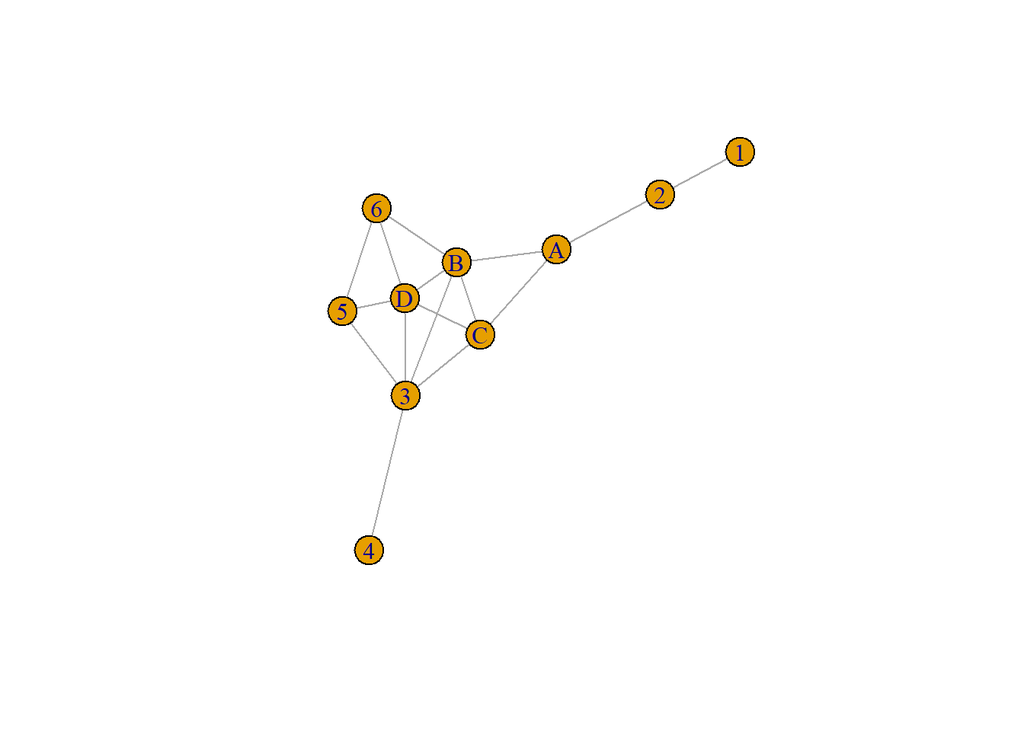

```r
graph <- graph_from_edgelist(edges, directed = FALSE)
# Plot the graph
plot(graph)
```

## Degree centrality

```r
# Calculate degree centrality for each node
degree_centrality <- degree(graph)

# Get degree centrality for nodes A, B, C, and D
A_degree <- degree_centrality["A"]
B_degree <- degree_centrality["B"]
C_degree <- degree_centrality["C"]
D_degree <- degree_centrality["D"]

# Print degree centrality for nodes A, B, C, and D
cat("Degree centrality for node A:", A_degree, "\n")
```

```
## Degree centrality for node A: 3
```

```r
cat("Degree centrality for node B:", B_degree, "\n")
```

```
## Degree centrality for node B: 5
```

```r
cat("Degree centrality for node C:", C_degree, "\n")
```

```
## Degree centrality for node C: 4
```

```r
cat("Degree centrality for node D:", D_degree, "\n")
```

```
## Degree centrality for node D: 5
```

## Closeness centrality

```r
# Calculate closeness centrality for each node
closeness_centrality <- closeness(graph)

# Get closeness centrality for nodes A, B, C, and D
A_closeness <- closeness_centrality["A"]
B_closeness <- closeness_centrality["B"]
C_closeness <- closeness_centrality["C"]
D_closeness <- closeness_centrality["D"]

# Print closeness centrality for nodes A, B, C, and D
cat("Closeness centrality for node A:", A_closeness, "\n")
```

```
## Closeness centrality for node A: 0.05882353
```

```r
cat("Closeness centrality for node B:", B_closeness, "\n")
```

```
## Closeness centrality for node B: 0.07142857
```

```r
cat("Closeness centrality for node C:", C_closeness, "\n")
```

```
## Closeness centrality for node C: 0.06666667
```

```r
cat("Closeness centrality for node D:", D_closeness, "\n")
```

```
## Closeness centrality for node D: 0.0625
```

## Betweenness centrality

```r
# Calculate betweenness centrality for each node
betweenness_centrality <- betweenness(graph)

# Get betweenness centrality for nodes A, B, C, and D
A_betweenness <- betweenness_centrality["A"]
B_betweenness <- betweenness_centrality["B"]
C_betweenness <- betweenness_centrality["C"]
D_betweenness <- betweenness_centrality["D"]

# Print betweenness centrality for nodes A, B, C, and D
cat("Betweenness centrality for node A:", A_betweenness, "\n")
```

```
## Betweenness centrality for node A: 14
```

```r
cat("Betweenness centrality for node B:", B_betweenness, "\n")
```

```
## Betweenness centrality for node B: 10.46667
```

```r
cat("Betweenness centrality for node C:", C_betweenness, "\n")
```

```
## Betweenness centrality for node C: 5.7
```

```r
cat("Betweenness centrality for node D:", D_betweenness, "\n")
```

```
## Betweenness centrality for node D: 3.2
```

My seat of choice would be seat B.

If the goal is to optimize for closeness to other seats: Seat B has a relatively high closeness centrality score compared to other seats in the network, which indicates that it is located close to many other seats. Choosing seat B could help to facilitate communication with nearby seats and minimize travel time between them.

If the goal is to optimize for maximizing the number of connections: Seat B is connected to five other seats, which is higher than the average number of connections for seats in this network. Choosing seat B could help to maximize the number of potential connections.

Overall, it seems that seat B is a right candidate for a good seat. The only concern it might have is that it is located near the luggage area and could cause injuries if the bus driver suddenly hit the brake.